# DMI - Hands on 3: Machine Learning to classify COVID-19 severity

Classification of COVID-19 clinical outcomes through Random Forest modeling

Maria Pau Pijoan Manresa (mariapau.pijoan01@estudiant.upf.edu)

Last update: 26 March, 2026

# 1 Exercise 1 - Build a Random Forest model to classify COVID-19 severity

## 1.1 Introduction

Proteomic profiling provides a powerful approach to characterize systemic biological responses to infection. By measuring circulating protein levels, it is possible to identify molecular signatures associated with disease severity. Machine learning methods are particularly well suited for analyzing high-dimensional omics data, as they can capture complex, non-linear relationships between predictors and clinical outcomes. In this analysis, we aim to develop a classification model to distinguish between severe and non-severe COVID-19 patients using proteomic data. A Random Forest algorithm is implemented due to its robustness, ability to handle high-dimensional data, and built-in feature importance estimation. The workflow includes data preprocessing, missing value handling, feature filtering, model training, hyperparameter tuning, and performance evaluation using cross-validation and an internal test set. Model performance is assessed using metrics such as accuracy, sensitivity, specificity, and the area under the ROC curve (AUC). This approach allows us to evaluate the predictive potential of proteomic biomarkers and assess the reliability of machine learning models in a clinical classification setting.

## 1.2 Data Preparation

### 1.2.1 Loading required packages

```r
# install.packages("readxl")
# install.packages("tidyverse")
# install.packages("janitor")
# install.packages("caTools")
# install.packages("randomForest")
# install.packages("tidymodels")
# install.packages("parsnip")
# install.packages("caret")
# install.packages("recipies")
# install.packages("pROC")
```

### 1.2.2 Importing proteomic data and libraries

```r
library(tidyverse)
library(readxl)
library(janitor) #clean_names function
library(dplyr)
library(caret)
library(recipes)
library(pROC)
library(rsample)
library(randomForest)

df <- read_excel("./1-s2.0-S0092867420306279-mmc3.xlsx", sheet = 2)
df_cleaned <- clean_names(df)

df_metdata <- read_excel("./1-s2.0-S0092867420306279-mmc1.xlsx", sheet = 2)
df_metdata_cleaned <- clean_names(df_metdata)
```

### 1.2.3 Data reshaping and cleaning

Now we have patients in columns and proteins in rows. To run most analysis, the structure needs to be flipped.

- Columns (variable) –> something we measure (proteins)
- Rows (observations) –> individual entity (patients)

```r
#Extract actual patients IDs from the first row
new_headers <- df_cleaned[1, ] %>%
  select(patient_id:last_col()) %>% #start at patient_id til the enc
  unlist() %>%
  as.character()

#Rename the columns of the dataframe uing these real patient IDs
colnames(df_cleaned)[3:ncol(df_cleaned)] <- new_headers
#Columns 1 and 2 stay as they are, only columns 3 to onwards become XG1, XG2, etc

#Now transpose the table!
df_cleaned_final <- df_cleaned %>%
  slice(-1) %>% # Remove that first row now that we've used it for names
  slice(1:791) %>%                       # Select rows 1 through 791
  pivot_longer(
    cols = all_of(new_headers),         # Pivot all the patient columns (XG1, XG2...)
    names_to = "patient_id",            # New column to hold the patient names
    values_to = "expression"            # New column to hold the numeric values
  ) %>%
  select(-gene_symbol) %>%
  pivot_wider(
    names_from = proteins_metabolites,
    values_from = expression
  ) %>%
  # Convert the protein columns to numeric for the random forest
  mutate(across(-patient_id, as.numeric))


colnames(df_metdata_cleaned)[1] <- "patient_id" #changed the name from patient_id_a to patient_id to match the column names between the 2 dataframes

#Added in the df_final the group_d (severity) from df_metdata_cleaned
df_metdata_cleaned <- df_metdata_cleaned %>% select(patient_id, group_d)
```

### 1.2.4 Merging clinical metadata

```r
df_final <- left_join(df_cleaned_final, df_metdata_cleaned, by = "patient_id") #2:non-Severe; 3: Severe
#As this data contains also non-COVID and healthy patients, and the exercise tells to filter only between non-severe and severe, I will filter the df_final to only have non-severe and severe patients (only 2 and 3).

df_final <- df_final %>%
  filter(group_d %in% c(2, 3)) %>%
  mutate(group_d = factor(group_d, levels = c(2,3), labels = c("non_Severe", "Severe"))) %>%
  select(-patient_id) #remove ID so it's not used as a predictor
table(df_final$group_d) #to see how many non-severe and severe patients are there and if we have removed the other groups correctly
```

```
##
## non_Severe     Severe
##         18         13
```

```r
#Now df_final contains all proteins in columns, patients in rows and in the last column it appears group_d (and only contians non-severe and severe patients)
```

## 1.3 Missing data handling

### 1.3.1 Exploratory NA analysis

```r
#Now let's see the NA values (because RF cannot work if there are NA values)
sum(is.na(df_final)) #Total NA values
```

```
## [1] 7262
```

### 1.3.2 Removing proteins with >20% missing values

Remove proteins with more than 20% missing values (this removes unreliable features). Because if a protein is missing in 80% of the patients, and I fill those gaps with the median of the 20% who actually had it, I am essentially inventing 80% of the data. And therefore, the RF might find a pattern in that protein, but that protein isn’t biological, it’s just a result of my imputation method!!!

```r
na_threshold <- 0.2
cols_to_keep <- colMeans(is.na(df_final)) <= na_threshold
df_final_0.2_removed <- df_final[ , cols_to_keep]
```

At this point, we have removed some proteins that contained more than 20% missing values.

### 1.3.3 Median imputation

```r
df_final_cleaned <- df_final_0.2_removed %>%
  mutate(across(where(is.numeric), ~ifelse(is.na(.), median(., na.rm = TRUE), .)))
sum(is.na(df_final_cleaned)) #now we have imputed the remaining NAs with the median
```

```
## [1] 0
```

### 1.3.4 Final feature cleaning

```r
#clean the columns in the df_final_cleaned becasue RF algorithm got crazy
df_final_cleaned <- df_final_cleaned %>%
  clean_names()
```

## 1.4 Initial random forest model (manual approach)

At this point, I have obtained a tidy data format necessary for ML. As we have ~800 proteins (features) but very few patients, Random Forest model is a great choice because it handles “wide” data well.

```r
rf_model <- randomForest(as.factor(group_d) ~ .,
                         data = df_final_cleaned,
                         importance = TRUE, #essential for exercise 2, where need to identify the top 25 proteins. so it tells R to calculate which proteins were most helpful in splitting the severe from non-severe groups
                         ntree = 500)

print(rf_model)
```

```
##
## Call:
##  randomForest(formula = as.factor(group_d) ~ ., data = df_final_cleaned,      importance = TRUE, ntree = 500)
##                Type of random forest: classification
##                      Number of trees: 500
## No. of variables tried at each split: 20
##
##         OOB estimate of  error rate: 16.13%
## Confusion matrix:
##            non_Severe Severe class.error
## non_Severe         16      2   0.1111111
## Severe              3     10   0.2307692
```

## 1.5 Structured machine learning workflow (Recipe-Based Approach)

Recipe packages makes the workflow more professional, reproducible, and robust. Defines the data preprocessing steps as a “blueprint” and in exercise 3 when doing the test, I won’t have to manually repeat the cleaning, just apply this blueprint.

### 1.5.1 Cohort splitting (80/20 Stratified Split)

```r
# Prepare data
# Ensure names are clean and variables are ready
df_final_preclean <- df_final %>% janitor::clean_names()

#--- COHORT SPLIT & INTERNAL DIVISION ------
set.seed(123)

#Create an 80/20 split stratified by the outcome (group_d)
data_split <- initial_split(df_final_preclean, prop = 0.8, strata = group_d)

#Development cohort (80%)
training_data <- training(data_split) #will have 24 observation, which is a 0.8% of the 31 ones initially

#Internal testing (20%)
internal_test_data <- testing(data_split)
```

### 1.5.2 Cross-Validation setup (10-Fold CV)

```r
#Define the recipe (blueprint) (THIS IS DONE IN THE TEACHER SLIDES!!!!)
rf_recipe <- recipe(group_d ~ ., data = training_data) %>%
  step_nzv(all_predictors()) %>%
  step_impute_median(all_numeric_predictors()) %>%
  step_normalize(all_numeric_predictors())

# set up training controls
# This handles the 10-fold CV and collects data for the ROC curve
ctrl <- trainControl(
  method = "cv",
  number = 10,
  savePredictions = "final",       # Necessary to plot the ROC later
  classProbs = TRUE,               # Necessary for AUC calculation
)
```

### 1.5.3 Hyperparameter tuning (mtry Grid)

```r
# Define tuning grid
# Testing different numbers of predictors at each split
p <- ncol(df_final_preclean) - 1
mtry_grid <- data.frame(mtry = c(1, 2, floor(sqrt(p)), floor(p/3), 10, 30))
```

### 1.5.4 Model training with caret

```r
rf_model_2 <- train(
  rf_recipe,
  data = training_data,
  method = "rf",
  trControl = ctrl,
  tuneGrid = mtry_grid,
  metric = "Accuracy",
  ntree = 500,
  importance = TRUE
)
```

## 1.6 Model evaluation

### 1.6.1 Cross-Validation performance

```r
#------ RESULTS ANALYSIS------

# Performance during Cross-validation (the 80%)
print(rf_model_2)
```

```
## Random Forest
##
##  24 samples
## 791 predictors
##   2 classes: 'non_Severe', 'Severe'
##
## Recipe steps: nzv, impute_median, normalize
## Resampling: Cross-Validated (10 fold)
## Summary of sample sizes: 22, 22, 22, 22, 21, 21, ...
## Resampling results across tuning parameters:
##
##   mtry  Accuracy   Kappa
##     1   0.7333333  0.40
##     2   0.7333333  0.44
##    10   0.8666667  0.74
##    28   0.8666667  0.74
##    30   0.8666667  0.74
##   263   0.8666667  0.74
##
## Accuracy was used to select the optimal model using the largest value.
## The final value used for the model was mtry = 10.
```

### 1.6.2 Internal hold-out test performance

```r
# Performance on the Internal Hold-out (the 20%)
## This proves the model works on "unseen" data before going to the external cohort
internal_preds <- predict(rf_model_2, newdata = internal_test_data)
internal_cm <- confusionMatrix(internal_preds, internal_test_data$group_d)

print("----Internal 20% test results:-----")
```

```
## [1] "----Internal 20% test results:-----"
```

```r
print(internal_cm)
```

```
## Confusion Matrix and Statistics
##
##             Reference
## Prediction   non_Severe Severe
##   non_Severe          3      2
##   Severe              1      1
##
##                Accuracy : 0.5714
##                  95% CI : (0.1841, 0.901)
##     No Information Rate : 0.5714
##     P-Value [Acc > NIR] : 0.6531
##
##                   Kappa : 0.087
##
##  Mcnemar's Test P-Value : 1.0000
##
##             Sensitivity : 0.7500
##             Specificity : 0.3333
##          Pos Pred Value : 0.6000
##          Neg Pred Value : 0.5000
##              Prevalence : 0.5714
##          Detection Rate : 0.4286
##    Detection Prevalence : 0.7143
##       Balanced Accuracy : 0.5417
##
##        'Positive' Class : non_Severe
##
```

### 1.6.3 ROC curve and AUC

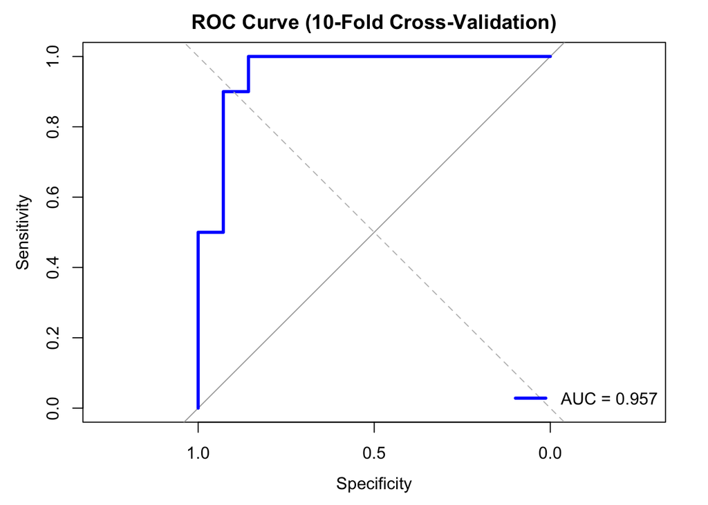

```r
# Plot the Realistic ROC Curve
# Using the cross-validated predictions (prevents the "perfect square" look)
roc_obj <- roc(rf_model_2$pred$obs, rf_model_2$pred$Severe)

# Draw the plot (this creates 'plot.new' inside the file)
{
  plot(roc_obj, col = "blue", lwd = 3, main = "ROC Curve (10-Fold Cross-Validation)")

#Add the lines (these will now work)
abline(a = 0, b = 1, lty = 2, col = "grey")

# Add the legend
legend("bottomright",
       legend = paste("AUC =", round(auc(roc_obj), 3)),
       col = "blue",
       lwd = 3,
       bty = "n")

}
```

## 1.7 Interpretation and discussion

The difference in performance is largely due to how each approach handles the data:

- Manual model performance: This model utilized all 31 samples (18 non-Severe, 13 Severe) to calculate its error estimate. By manually filtering proteins with >20% NAs, it likely retained a more concentrated set of high-quality predictors.
- Recipe-based model performance: This model was restricted to a smaller training set (80% of the cohort) to maintain strict architectural separation. Because it had fewer samples to learn from, its accuracy on the internal 20% hold-out was naturally lower at 57,14%.
- Feature handling: The recipe model utilizes `step_nzv()`, which is a conservative filter that removes variables with near-zero variance. This may have kept “noisy” proteins that the manual model’s stricter NA threshold successfully eliminated.

To further validate the model, the ROC Curve and the Confusion Matrix were analyzed. The model achieves an outstanding AUC (Area Under the Curve) of 0.957. This indicates a roughly ~96% probability that the model will correctly rank a randomly chosen Severe patient higher (in terms of severity risk) than a non-Severe patient.

## 1.8 Conclusion

All in all, the proteomic signature is clearly a strong biological marker for disease severity. The model demonstrates high potential, as shown by the outstanding AUC of 0.957 and the sharp rise in the ROC curve. However, the drop from 86.67% accuracy during training (cross-validation) to 57.14% in the internal test suggests significant overfitting—likely due to the high number of predictors (791 proteins) compared to the small number of samples (24 patients in the training set).

# 2 Exercise 2 – Differential Expression / Biomarker Discovery Analysis

## 2.1 Objective and overview

The goal of Exercise 2 is to identify and characterize proteins that are significantly associated with differences between predefined clinical groups. Through differential expression analysis and statistical testing, we aim to detect potential biomarkers that distinguish between conditions of interest and evaluate their biological and clinical relevance.

The analysis is based on a proteomic expression dataset containing quantitative measurements of circulating proteins across multiple patient samples. These measurements are integrated with corresponding clinical metadata, including group classification variables that define the comparison of interest (e.g., disease status, severity, or treatment group). The study follows a comparative observational design in which protein expression levels are statistically compared between groups. Appropriate preprocessing, quality control and multiple testing correction procedures are applied to ensure robust and reproducible results.

## 2.2 Data Loading and setup

### 2.2.1 Required packages

```r
# install.packages("tidyverse")
# install.packages("caret")
# install.packages("janitor")
# install.packages("dplyr")
# install.packages("ggplot2")
# install.packages(c("iml", "fastshap"))
# install.packages("pheatmap")  # if not installed
library(pheatmap)
library(tidyverse)
library(caret)
library(janitor)
library(dplyr) #for calibration plot
library(ggplot2) #for calibration plot
library(iml) #for SHAP analysis
library(fastshap) #for SHAP analysis
```

## 2.3 Top 25 proteins and importing data

```r
# extract importance
importance_results <- varImp(rf_model_2, scale = FALSE)

# create top 25 list
top_25_list <- importance_results$importance %>%
  as.data.frame() %>%
  rownames_to_column(var = "Protein_ID") %>%
  # Fix the case: Ensure Protein_ID is Uppercase to match the metadata
  mutate(Protein_ID = toupper(Protein_ID)) %>%
  arrange(desc(Severe)) %>%
  slice_head(n = 25)

#prepare comparison data
# We load the metadata and ensure the mapping ID is also Uppercase
df_table_5_meta <- read_excel("./1-s2.0-S0092867420306279-mmc5.xlsx", sheet = 2) %>%
  clean_names() %>%
  slice(-1) %>% # Remove the row used for patient IDs
  select(proteins_metabolites, gene_symbol) %>%
  distinct() %>%
  mutate(proteins_metabolites = toupper(proteins_metabolites))

# merge
# Note: 'Protein_ID' from your list matches 'proteins_metabolites' from the metadata
top_25_named <- top_25_list %>%
  left_join(df_table_5_meta, by = c("Protein_ID" = "proteins_metabolites"))
```

## 2.4 Results visualization

### 2.4.1 Variable importance plot

```r
# view results
print(top_25_named)
```

```
##    Protein_ID non_Severe   Severe gene_symbol
## 1      P00738   2.740069 2.740069          HP
## 2      P07195   2.543734 2.543734        <NA>
## 3      Q9UK55   2.376937 2.376937   SERPINA10
## 4      P02763   2.347448 2.347448        <NA>
## 5      P18428   2.318182 2.318182         LBP
## 6      P35542   2.257043 2.257043        <NA>
## 7      P12259   2.219482 2.219482          F5
## 8      P02768   2.218940 2.218940         ALB
## 9      P02750   2.166399 2.166399        LRG1
## 10     P02766   2.100714 2.100714        <NA>
## 11     Q06033   2.068284 2.068284       ITIH3
## 12     P13796   2.009906 2.009906        LCP1
## 13     P0DJI8   1.974187 1.974187        SAA1
## 14     P01009   1.970746 1.970746        <NA>
## 15     P51884   1.942013 1.942013         LUM
## 16     P0DJI9   1.932018 1.932018        SAA2
## 17     P00338   1.881104 1.881104        <NA>
## 18     P04196   1.868738 1.868738        <NA>
## 19     P02748   1.866556 1.866556          C9
## 20     Q86UD1   1.865377 1.865377         OAF
## 21     P22105   1.801070 1.801070        <NA>
## 22     P02741   1.776250 1.776250         CRP
## 23     P18065   1.735850 1.735850        <NA>
## 24     P03951   1.725713 1.725713        <NA>
## 25     P05155   1.678573 1.678573    SERPING1
```

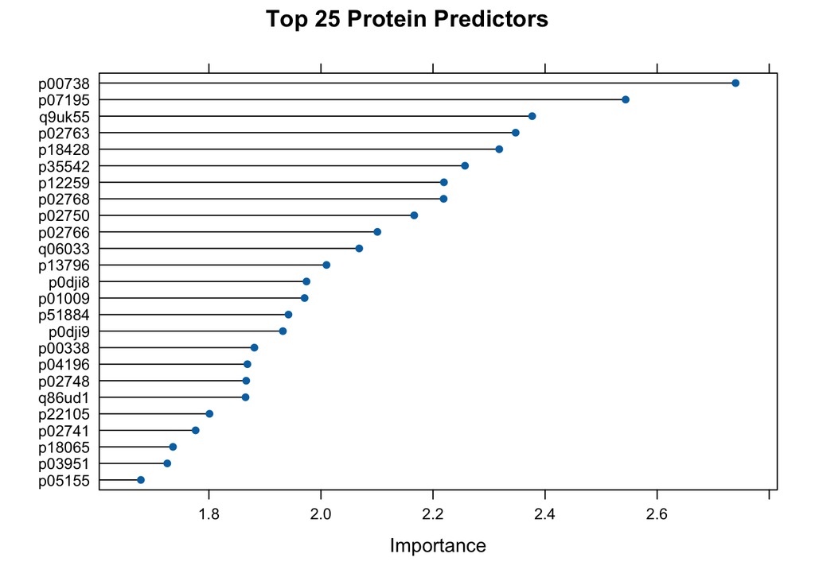

```r
# plot
plot(importance_results, top = 25, main = "Top 25 Protein Predictors")
```

### 2.4.2 Volcano plot

```r
library(dplyr)
library(ggplot2)
library(ggrepel)

#Pick the top 25 proteins from your RF importance table
top_proteins <- tolower(top_25_named$Protein_ID)


# Choose the dataset that contains protein values + group labels
df <- df_final_cleaned  # <-- CHANGE THIS to your training dataset object


# Compute log2FC (Severe vs non_Severe) + p-values for those proteins -
volcano_df <- lapply(top_proteins, function(p) {

  if (!p %in% colnames(df)) return(NULL)

  x_sev <- df %>% filter(group_d == "Severe") %>% pull(!!sym(p))
  x_non <- df %>% filter(group_d == "non_Severe") %>% pull(!!sym(p))

  x_sev <- x_sev[is.finite(x_sev)]
  x_non <- x_non[is.finite(x_non)]

  if (length(x_sev) < 2 || length(x_non) < 2) return(NULL)

  # Robust effect size: median log2 fold change
  log2fc <- log2(median(x_sev) + 1e-9) - log2(median(x_non) + 1e-9)

  # Robust test for omics distributions
  pval <- suppressWarnings(wilcox.test(x_sev, x_non)$p.value)

  data.frame(Protein_ID = p, log2FC = log2fc, p_value = pval)
}) %>%
  bind_rows() %>%
  mutate(
    p_adj = p.adjust(p_value, method = "BH"),
    negLog10FDR = -log10(p_adj),
    Significant = p_adj < 0.05 & abs(log2FC) >= 1
  )

# Volcano plot dataframe to see most variable gene symbols
volcano_df <- volcano_df %>%
  left_join(
    top_25_named %>%
      mutate(Protein_ID = tolower(Protein_ID)) %>%
      select(Protein_ID, gene_symbol),
    by = "Protein_ID"
  ) %>%
  mutate(Label = ifelse(!is.na(gene_symbol) & gene_symbol != "", gene_symbol, Protein_ID))


# Volcano plot dataframe to see most variable proteins
volcano_df_proteins <- volcano_df %>%
  left_join(
    top_25_named %>%
      mutate(Protein_ID = tolower(Protein_ID)) %>%
      select(Protein_ID, gene_symbol),
    by = "Protein_ID"
  ) %>%
  # CHANGE THIS LINE: Use Protein_ID for the label instead of gene_symbol
  mutate(Label = Protein_ID)

# The rest of your ggplot code stays the same!

# See top10 proteins having high log2FC
top_10_significant <- volcano_df %>%
  arrange(desc(abs(log2FC))) %>%     # Sorts from smallest to largest p-value
  slice_head(n = 10)      # Takes the first 10 rows

print(top_10_significant)
```

```
##    Protein_ID     log2FC      p_value        p_adj negLog10FDR Significant
## 1      p0dji8  3.1712405 2.009416e-05 1.278042e-04    3.893455        TRUE
## 2      p0dji9  2.5881649 4.363571e-07 1.090893e-05    4.962218        TRUE
## 3      p02741  1.8099396 6.788211e-05 1.542775e-04    3.811697        TRUE
## 4      p18428  1.0708968 2.556083e-05 1.278042e-04    3.893455        TRUE
## 5      p02748  0.9668743 3.276557e-05 1.305132e-04    3.884346       FALSE
## 6      p02763  0.7885818 4.176423e-05 1.305132e-04    3.884346       FALSE
## 7      p00738  0.7303615 1.161680e-05 1.278042e-04    3.893455       FALSE
## 8      p02750  0.7291134 4.176423e-05 1.305132e-04    3.884346       FALSE
## 9      q06033  0.5890299 5.287679e-05 1.430258e-04    3.844586       FALSE
## 10     p04196 -0.5353317 2.328188e-03 3.063406e-03    2.513795       FALSE
##    gene_symbol  Label
## 1         SAA1   SAA1
## 2         SAA2   SAA2
## 3          CRP    CRP
## 4          LBP    LBP
## 5           C9     C9
## 6         <NA> p02763
## 7           HP     HP
## 8         LRG1   LRG1
## 9        ITIH3  ITIH3
## 10        <NA> p04196
```

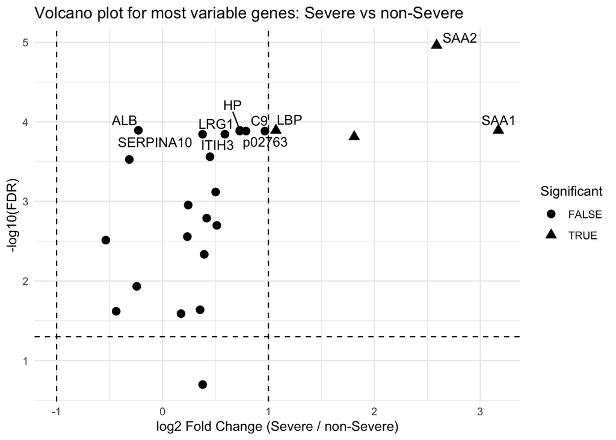

```r
ggplot(volcano_df, aes(x = log2FC, y = negLog10FDR)) +
  geom_point(aes(shape = Significant), size = 3) +
  geom_vline(xintercept = c(-1, 1), linetype = "dashed") +
  geom_hline(yintercept = -log10(0.05), linetype = "dashed") +
  ggrepel::geom_text_repel(
    data = volcano_df %>% arrange(p_adj) %>% slice(1:10),
    aes(label = Label),
    max.overlaps = 30
  ) +
  labs(
    title = "Volcano plot for most variable genes: Severe vs non-Severe",
    x = "log2 Fold Change (Severe / non-Severe)",
    y = "-log10(FDR)"
  ) +
  theme_minimal()
```

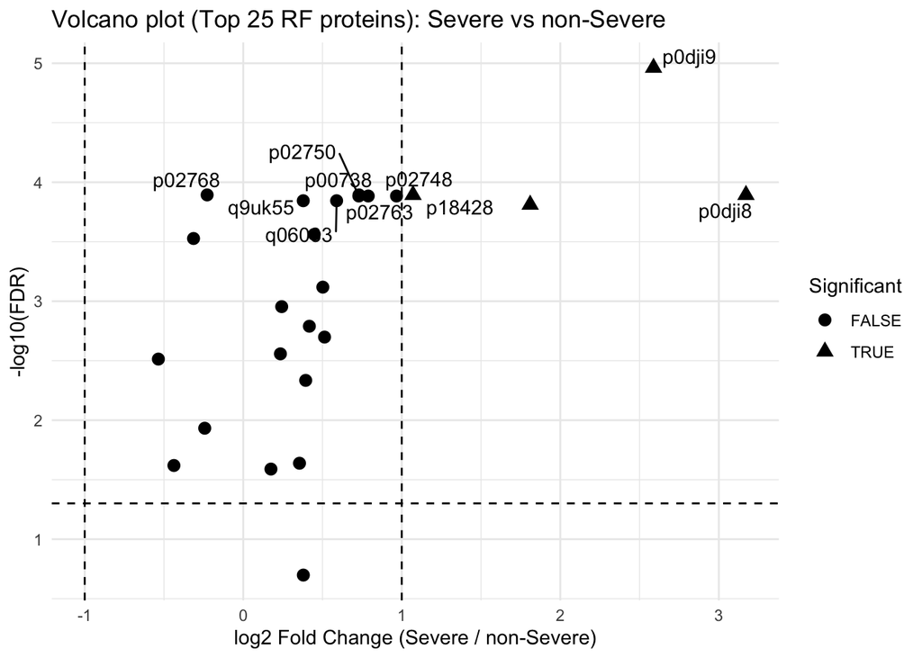

```r
ggplot(volcano_df_proteins, aes(x = log2FC, y = negLog10FDR)) +
  geom_point(aes(shape = Significant), size = 3) +
  geom_vline(xintercept = c(-1, 1), linetype = "dashed") +
  geom_hline(yintercept = -log10(0.05), linetype = "dashed") +
  ggrepel::geom_text_repel(
    data = volcano_df_proteins %>% arrange(p_adj) %>% slice(1:10),
    aes(label = Label),
    max.overlaps = 30
  ) +
  labs(
    title = "Volcano plot (Top 25 RF proteins): Severe vs non-Severe",
    x = "log2 Fold Change (Severe / non-Severe)",
    y = "-log10(FDR)"
  ) +
  theme_minimal()
```

Protein ID,Gene Symbol,log2FC,Fold Change (linear)

p0dji8,SAA1,3.17,~9.0x higher

p0dji9,SAA2,2.59,~6.0x higher

p02741,CRP,1.81,~3.5x higher

p18428,LBP,1.07,~2.1x higher

Key inflammatory markers such as SAA1 (log2FC = 3.17), SAA2 (log2FC = 2.59) and CRP (log2FC = 1.81) show massive fold changes, indicating they are much more abundant in severe patients. These proteins demonstrated both statistical significance (FDR < 0.05) and substantial effect sizes (log2FC > 1.0). In particular, SAA1 showed a log2FC of 3.17, representing a nearly 9-fold increase in protein abundance in Severe patients, highlighting a massive systemic inflammatory response. Doing some bibliographic research on these markers, SAA1 & SAA2 (Serum Amyloid A1/2) are highly sensitive markers of inflammation. They help recruit immune cells to inflammatory sites but, when chronically high, can contribute to lung tissue damage and hyper-inflammation seen in severe COVID-19. As for CRP, it binds to the surface of dead or dying cells and some bacteria to help the complement system clear them out. High CRP is one of the most consistent predictors of needing mechanical ventilation in COVID-19 patients. Although LBP is usually associated with bacterial infections, it is significantly elevated in severe COVID-19. It indicates a breach in “barrier integrity” (like the gut or lung lining), allowing microbial components to leak into the blood and worsen the inflammatory spiral. So, overall all these inflammatory markers creates a highly accurate fingerprint of a patient in a severe clinical state.

The volcano plot (Volcano plot (Top 25 RF proteins): Severe vs non-Severe) and the Variance important plot (Top 25 Protein Predictors) highlights the fundamental difference between Univariate Statistics (the volcano plot) and multivariate ML (the Variable Importance Plot). The volcano plot looks at each protein one by one, while the varibale importance plot (multivairate) looks at combinations. Moreover, the volcano plot will show every protein that is different. If 10 proteins are all part of the same biological pathway, all 10 will show up as significant on the volcano plot. However, RF doesn’t like redundancy. If protein A and protein B provide the exact same information, the RF might only give a high “Importance” score to one of them and ignore the other. So, to sum up, there is a divergence between the top proteins identified by the volcano plot and the RF Variable Importance. This is expected, as the volcano plot identifies individual proteins with the largest magnitude of change (univariate), while the RF identifies the most predictive features in a multivariate context. Proteins that appear important to the model but less significant in the volcano plot likely provide high classification stability or act as crucial ‘tie-breakers’ when combined with other markers.

### 2.4.3 Heatmap of significant features

```r
library(pheatmap)
library(dplyr)

# Intersect (uppercase for matching only)
significant_proteins_upper <- intersect(
  toupper(top_25_named$Protein_ID),
  toupper(colnames(training_data))
)

cat("Matched proteins:", length(significant_proteins_upper), "\n")
```

```
## Matched proteins: 25
```

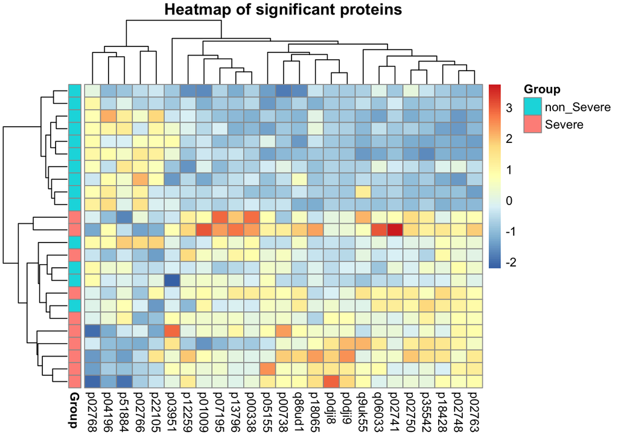

```r
# Get the ORIGINAL lowercase column names from training_data
matched_cols <- colnames(training_data)[toupper(colnames(training_data)) %in% significant_proteins_upper]


heatmap_data <- training_data %>%
  select(all_of(matched_cols), group_d)

expr_matrix <- heatmap_data %>%
  select(-group_d) %>%
  as.matrix()

# 2) Give the matrix valid rownames (must match annotation_row rownames)
rownames(expr_matrix) <- paste0("S", seq_len(nrow(expr_matrix)))

# 3) Scale by protein (column-wise) -> keep same rownames
expr_matrix_scaled <- scale(expr_matrix)

# 4) Annotation with matching rownames
annotation_df <- data.frame(Group = heatmap_data$group_d)
rownames(annotation_df) <- rownames(expr_matrix_scaled)

# 5) Plot
pheatmap(
  expr_matrix_scaled,
  annotation_row = annotation_df,
  cluster_rows = TRUE,
  cluster_cols = TRUE,
  show_rownames = FALSE,
  main = "Heatmap of significant proteins"
)
```

## 2.5 Biological interpretation

### 2.5.1 Annotation / Feature mapping

```r
# Make sure Protein_ID in volcano_df matches case
volcano_df$Protein_ID <- tolower(volcano_df$Protein_ID)
top_25_named$Protein_ID <- tolower(top_25_named$Protein_ID)

feature_mapping <- top_25_named %>%
  left_join(
    volcano_df %>%
      select(Protein_ID, log2FC, p_adj),
    by = "Protein_ID"
  ) %>%
  arrange(desc(Severe))   # Severe column = RF importance score

print(feature_mapping)
```

```
##    Protein_ID non_Severe   Severe gene_symbol     log2FC        p_adj
## 1      p00738   2.740069 2.740069          HP  0.7303615 1.278042e-04
## 2      p07195   2.543734 2.543734        <NA>  0.3548172 2.298632e-02
## 3      q9uk55   2.376937 2.376937   SERPINA10  0.3785116 1.430258e-04
## 4      p02763   2.347448 2.347448        <NA>  0.7885818 1.305132e-04
## 5      p18428   2.318182 2.318182         LBP  1.0708968 1.278042e-04
## 6      p35542   2.257043 2.257043        <NA>  0.5019382 7.612700e-04
## 7      p12259   2.219482 2.219482          F5  0.2425872 1.110568e-03
## 8      p02768   2.218940 2.218940         ALB -0.2277327 1.278042e-04
## 9      p02750   2.166399 2.166399        LRG1  0.7291134 1.305132e-04
## 10     p02766   2.100714 2.100714        <NA> -0.4373424 2.400777e-02
## 11     q06033   2.068284 2.068284       ITIH3  0.5890299 1.430258e-04
## 12     p13796   2.009906 2.009906        LCP1  0.4170211 1.622112e-03
## 13     p0dji8   1.974187 1.974187        SAA1  3.1712405 1.278042e-04
## 14     p01009   1.970746 1.970746        <NA>  0.2344653 2.768066e-03
## 15     p51884   1.942013 1.942013         LUM -0.3135734 2.970342e-04
## 16     p0dji9   1.932018 1.932018        SAA2  2.5881649 1.090893e-05
## 17     p00338   1.881104 1.881104        <NA>  0.3938987 4.625760e-03
## 18     p04196   1.868738 1.868738        <NA> -0.5353317 3.063406e-03
## 19     p02748   1.866556 1.866556          C9  0.9668743 1.305132e-04
## 20     q86ud1   1.865377 1.865377         OAF  0.5129224 2.000851e-03
## 21     p22105   1.801070 1.801070        <NA> -0.2429859 1.167412e-02
## 22     p02741   1.776250 1.776250         CRP  1.8099396 1.542775e-04
## 23     p18065   1.735850 1.735850        <NA>  0.3791179 2.001394e-01
## 24     p03951   1.725713 1.725713        <NA>  0.1747146 2.573269e-02
## 25     p05155   1.678573 1.678573    SERPING1  0.4481382 2.741664e-04
```

## 2.6 Conclusions

The gene symbols appearing next to protein IDs (like SAA1, CRP and HP) mean that the model successfully identified the same high-level biological markers that the researchers focused on. In the raw data, these are just technical accession numbers (like P02741), but by mapping them to gene symbols, it has been proven that the model “picked” the COVID-19 markers. If a protein has a gene symbol in the table, it is a known, named protein that the researchers also analyzed.

Based on the shared results obtained in this table, SAA1, SAA2 and CRP are the primary markers of the cytokine storm and systemic inflammation. SERPING1 and SERPINA10 indicate the activation of the body’s innate defense and blood-clotting regulations. LUM and ITIH3 are linked to how the body repairs or scars connective tissue, particularly in the lungs.

# 3 Exercise 3 – External Validation of the Random Forest Model

## 3.1 Objective

- Evaluate the generalizability of the trained Random Forest model
- Assess performance on an independent external cohort

## 3.2 Independent test cohort preparation

### 3.2.1 Importing the external dataset

- Loading supplementary table data

```r
df_test_raw <- read_excel("./1-s2.0-S0092867420306279-mmc4.xlsx", sheet = 2) %>%
  clean_names()
```

- Cleaning column names and clinical label definition

```r
#Comparison based on supplementary table 4
df_metdata_cleaned_2 <- df_metdata_cleaned %>%
  mutate(
    group = case_when(
      group_d %in% c(0, 1) ~ "Non-COVID-19",
      group_d == 2 ~ "Non-severe",
      group_d == 3 ~ "Severe",
      TRUE ~ NA_character_
    ),
    group = factor(group, levels = c("Non-severe", "Severe"))
  ) %>%
  select(patient_id, group) %>%
  filter(group %in% c("Non-severe", "Severe"))
```

### 3.2.2 Data reshaping and formatting

- Header reconstruction

```r
new_headers <- df_test_raw[1, ] %>%
  select(patient_id:last_col()) %>%
  unlist() %>%
  as.character()
colnames(df_test_raw)[3:ncol(df_test_raw)] <- new_headers
```

- Pivoting to tidy format and convert expression values to numeric

```r
#pivot to tidy format
df_test_raw_final <- df_test_raw %>%
  slice(-1) %>%
  slice(1:742) %>%
  pivot_longer(
    cols = all_of(new_headers),
    names_to = "patient_id",
    values_to = "expression"
  ) %>%
  select(-gene_symbol) %>%
  pivot_wider(
    names_from = proteins_metabolites,
    values_from = expression
  ) %>%
  mutate(across(-patient_id, as.numeric))

df_test_with_labels <- df_test_raw_final %>%
  inner_join(df_metdata_cleaned_2, by = "patient_id") %>%
  mutate(group = recode(group, "Non-severe" = "non_Severe")) %>%
  mutate(group = factor(group, levels = c("non_Severe", "Severe"))) %>%
  clean_names()
```

## 3.3 Feature alignment with training model

### 3.3.1 Extracting model predictors

- Retrieving selected protein features from the trained model

```r
model_predictors <- rf_model_2$finalModel$xNames
# model_predictors
```

### 3.3.2 Handling missing features

- Identifying absent predictors
- Adding missing columns (NA padding)
- Ensuring identical feature structure

```r
missing_features <- setdiff(model_predictors, colnames(df_test_with_labels))
# missing_features

df_test_with_labels[missing_features] <- NA #Add the missing columns to the test set, filled with NAs
#This is done because RF requires the exact same column names in the exact order as the training data.

x_test <- df_test_with_labels %>%
  dplyr::select(all_of(model_predictors))
```

## 3.4 Model application to independent cohort

### 3.4.1 Generating class predictions and predicted probabilities

```r
#Predict disease severity
#use the rf_model_2 to see if it can correctly guess which proteins are severe
# predictions (make sure these are vectors, not data frames) --> Apply trained model to the test cohort
test_predictions <- predict(rf_model_2, newdata = x_test)
test_probabilities <- predict(rf_model_2, newdata = x_test, type = "prob")

# If predict() returned a data frame (tidymodels), extract the column:
if (is.data.frame(test_predictions)) test_predictions <- test_predictions$.pred

# Probabilities column name can differ: "Severe" (caret) vs ".pred_Severe" (tidymodels)
prob_severe <- if (is.data.frame(test_probabilities)) {
  if ("Severe" %in% colnames(test_probabilities)) test_probabilities$Severe else test_probabilities$.pred_Severe
} else {
  test_probabilities[, "Severe"]
}
```

### 3.4.2 Building the results table

```r
# Results table
test_results_table <- tibble(
  patient_id = df_test_with_labels$patient_id,
  Actual = df_test_with_labels$group,
  Predicted_Class = test_predictions,
  Prob_Severe = prob_severe
) %>%
  mutate(Correct = ifelse(Actual == Predicted_Class, "Correct", "Wrong"))

print(test_results_table)
```

```
## # A tibble: 10 × 5
##    patient_id Actual     Predicted_Class Prob_Severe Correct
##    <chr>      <fct>      <fct>                 <dbl> <chr>
##  1 XG20       non_Severe non_Severe            0.222 Correct
##  2 XG21       non_Severe non_Severe            0.452 Correct
##  3 XG22       non_Severe Severe                0.616 Wrong
##  4 XG44       Severe     Severe                0.708 Correct
##  5 XG43       Severe     Severe                0.746 Correct
##  6 XG23       non_Severe non_Severe            0.186 Correct
##  7 XG24       non_Severe non_Severe            0.226 Correct
##  8 XG25       non_Severe Severe                0.616 Wrong
##  9 XG46       Severe     Severe                0.608 Correct
## 10 XG45       Severe     Severe                0.508 Correct
```

### 3.4.3 Calibration plot and Brierer score

Recommended when n = 10. When converting the severe and non-severe cases, the ones that where wrongly assigned, patients XG25 and XG22, which were severe when actually they were non-severe, they have been correctly numerically assigned. In other words, instead of putting them a 1 (severe), they have a 0 for non-severe.

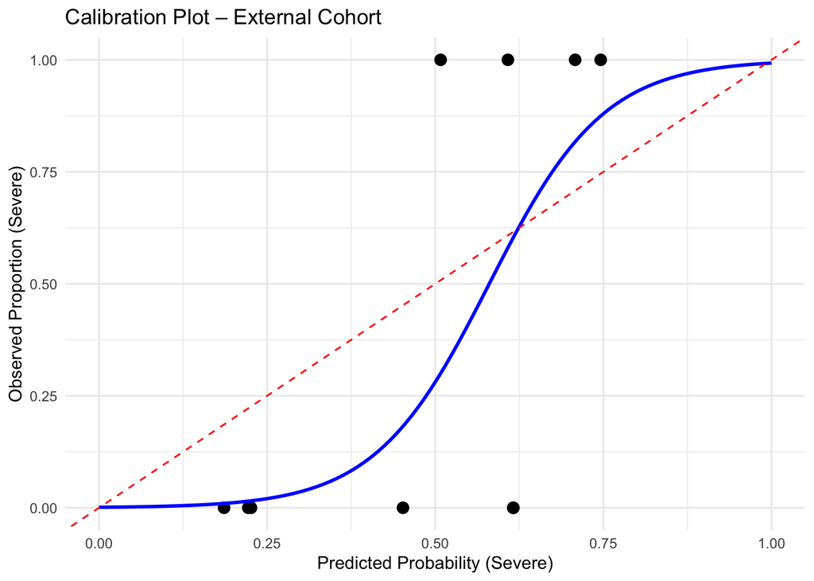

```r
# Convert actual class to numeric (1 = Severe, 0 = non_Severe)
calibration_df <- test_results_table %>%
  mutate(
    Actual_numeric = ifelse(Actual == "Severe", 1, 0)
  )

# Fit logistic regression of observed outcome vs predicted probability
calibration_model <- glm(Actual_numeric ~ Prob_Severe,
                         data = calibration_df,
                         family = binomial)

# Create smooth calibration curve
prob_seq <- seq(0, 1, length.out = 100)

calibration_curve <- data.frame(
  Prob_Severe = prob_seq,
  Observed = predict(calibration_model,
                     newdata = data.frame(Prob_Severe = prob_seq),
                     type = "response")
)

# Plot
ggplot(calibration_df, aes(x = Prob_Severe, y = Actual_numeric)) +
  geom_point(size = 3) +
  geom_line(data = calibration_curve,
            aes(x = Prob_Severe, y = Observed),
            color = "blue", linewidth = 1) +
  geom_abline(slope = 1, intercept = 0,
              linetype = "dashed",
              color = "red") +
  labs(
    title = "Calibration Plot – External Cohort",
    x = "Predicted Probability (Severe)",
    y = "Observed Proportion (Severe)"
  ) +
  theme_minimal()
```

```r
brier_score <- mean((calibration_df$Prob_Severe - calibration_df$Actual_numeric)^2)
brier_score
```

```
## [1] 0.164368
```

## 3.5 Performance evaluation on external cohort

### 3.5.1 Confusion matrix, accuracy, sensitivity, specificity and Cohen’s kappa

```r
# Confusion matrix (predicted vs truth)
final_metrics <- confusionMatrix(
  factor(test_results_table$Predicted_Class, levels = levels(test_results_table$Actual)),
  test_results_table$Actual,
  positive = "Severe"
)

print(final_metrics)
```

```
## Confusion Matrix and Statistics
##
##             Reference
## Prediction   non_Severe Severe
##   non_Severe          4      0
##   Severe              2      4
##
##                Accuracy : 0.8
##                  95% CI : (0.4439, 0.9748)
##     No Information Rate : 0.6
##     P-Value [Acc > NIR] : 0.1673
##
##                   Kappa : 0.6154
##
##  Mcnemar's Test P-Value : 0.4795
##
##             Sensitivity : 1.0000
##             Specificity : 0.6667
##          Pos Pred Value : 0.6667
##          Neg Pred Value : 1.0000
##              Prevalence : 0.4000
##          Detection Rate : 0.4000
##    Detection Prevalence : 0.6000
##       Balanced Accuracy : 0.8333
##
##        'Positive' Class : Severe
##
```

## 3.6 Discussion

### 3.6.1 Generalizability of the proteomic signature

The external validation results indicate that the proteomic signature identified during model training maintains strong discriminatory performance in an independent patient cohort. Achieving 80% accuracy and correctly identifying all Severe cases suggests that the selected protein predictors capture biologically meaningful patterns associated with disease severity. Importantly, the model was applied to fully independent data that underwent preprocessing using parameters derived exclusively from the training cohort, reducing the risk of information leakage. This strengthens confidence that the observed performance reflects true generalizability rather than overfitting to the original dataset.

### 3.6.2 Impact of small sample size (n = 10)

Despite the strong performance metrics, the small size of the external cohort (n = 10) limits the statistical certainty of the results. With such a small sample, a single misclassification substantially affects accuracy, specificity, and other derived metrics. Consequently, confidence intervals around these estimates are likely wide. The perfect sensitivity observed (1.00) is encouraging but should be interpreted cautiously, as performance estimates in small samples can be unstable. Therefore, while the findings are promising, they cannot be considered definitive evidence of robustness.

### 3.6.4 Need for larger-scale validation

Although the external validation results are encouraging, validation in larger and more diverse cohorts is essential before clinical application can be considered. Larger studies would allow for more precise estimation of performance metrics, assessment of calibration and evaluation across different demographic or clinical subgroups. Additionally, prospective validation in real-world clinical settings would be necessary to confirm reproducibility and practical utility. Future work should therefore focus on expanding cohort size and testing the model in independent populations to establish its reliability and clinical applicability.

# session info

R version 4.5.2 (2025-10-31) Platform: aarch64-apple-darwin20 Running under: macOS Tahoe 26.3

Matrix products: default BLAS: /System/Library/Frameworks/Accelerate.framework/Versions/A/Frameworks/vecLib.framework/Versions/A/libBLAS.dylib LAPACK: /Library/Frameworks/R.framework/Versions/4.5-arm64/Resources/lib/libRlapack.dylib; LAPACK version 3.12.1

locale: [1] en_US.UTF-8/en_US.UTF-8/en_US.UTF-8/C/en_US.UTF-8/en_US.UTF-8

time zone: Europe/Madrid tzcode source: internal

attached base packages: [1] stats graphics grDevices utils datasets methods base

other attached packages: [1] ggrepel_0.9.8 fastshap_0.1.1 iml_0.11.4  
[4] pheatmap_1.0.13 randomForest_4.7-1.2 rsample_1.3.2  
[7] pROC_1.19.0.1 recipes_1.3.1 caret_7.0-1  
[10] lattice_0.22-9 janitor_2.2.1 readxl_1.4.5  
[13] lubridate_1.9.5 forcats_1.0.1 stringr_1.6.0  
[16] dplyr_1.2.0 purrr_1.2.1 readr_2.2.0  
[19] tidyr_1.3.2 tibble_3.3.1 ggplot2_4.0.2  
[22] tidyverse_2.0.0

loaded via a namespace (and not attached): [1] rlang_1.1.7 magrittr_2.0.4 snakecase_0.11.1  
[4] furrr_0.3.1 otel_0.2.0 e1071_1.7-17  
[7] compiler_4.5.2 vctrs_0.7.2 reshape2_1.4.5  
[10] pkgconfig_2.0.3 fastmap_1.2.0 backports_1.5.0  
[13] labeling_0.4.3 utf8_1.2.6 rmarkdown_2.30  
[16] prodlim_2026.03.11 tzdb_0.5.0 xfun_0.57  
[19] cachem_1.1.0 jsonlite_2.0.0 parallel_4.5.2  
[22] R6_2.6.1 bslib_0.10.0 stringi_1.8.7  
[25] RColorBrewer_1.1-3 parallelly_1.46.1 rpart_4.1.24  
[28] jquerylib_0.1.4 cellranger_1.1.0 Rcpp_1.1.1  
[31] iterators_1.0.14 knitr_1.51 future.apply_1.20.2 [34] Metrics_0.1.4 Matrix_1.7-5 splines_4.5.2  
[37] nnet_7.3-20 timechange_0.4.0 tidyselect_1.2.1  
[40] rstudioapi_0.18.0 yaml_2.3.12 timeDate_4052.112  
[43] codetools_0.2-20 listenv_0.10.1 plyr_1.8.9  
[46] withr_3.0.2 S7_0.2.1 evaluate_1.0.5  
[49] future_1.70.0 survival_3.8-6 proxy_0.4-29  
[52] pillar_1.11.1 checkmate_2.3.4 foreach_1.5.2  
[55] stats4_4.5.2 generics_0.1.4 hms_1.1.4  
[58] scales_1.4.0 globals_0.19.1 class_7.3-23  
[61] glue_1.8.0 tools_4.5.2 data.table_1.18.2.1 [64] ModelMetrics_1.2.2.2 gower_1.0.2 grid_4.5.2  
[67] ipred_0.9-15 nlme_3.1-168 cli_3.6.5  
[70] lava_1.8.2 gtable_0.3.6 sass_0.4.10  
[73] digest_0.6.39 farver_2.1.2 htmltools_0.5.9  
[76] lifecycle_1.0.5 hardhat_1.4.2 MASS_7.3-65  
[79] sparsevctrs_0.3.6